# Kingsbury Homework 2

# WMAN 633 QUANTITATIVE ECOLOGY

### Set-up: Import the data and fit a model with OpenBeach as the response and an interaction between Year and BeachID.

```r
beach <- read.csv("beach.csv")
fit <- lm(OpenBeach ~ Year * BeachID, data = beach)
```

### Question 1

#### Calculate the residuals. Use the summary() function applied to your numeric vector of residuals to

#### verify that this matches the Residuals: quantiles reported from the summary of your fitted model.

#### Plot a histogram of your residuals. Do they appear reasonably Gaussian?

```r
#Inspect summary of the model and look at the Residuals
summary(fit)
```

```
Call:
lm(formula = OpenBeach ~ Year * BeachID, data = beach)

Residuals:
    Min      1Q  Median      3Q     Max
-80.203 -21.460  -1.434  13.385  89.529

Coefficients:
                Estimate Std. Error t value Pr(>|t|)
(Intercept)    36945.725   2547.493  14.503  < 2e-16 ***
Year             -18.365      1.272 -14.443  < 2e-16 ***
BeachIDB      -34211.979   3602.404  -9.497 2.87e-13 ***
BeachIDC      -28776.115   3602.404  -7.988 8.09e-11 ***
Year:BeachIDB     17.043      1.798   9.478 3.07e-13 ***
Year:BeachIDC     14.371      1.798   7.992 7.96e-11 ***
---
Signif. codes:  0 ‘***’ 0.001 ‘**’ 0.01 ‘*’ 0.05 ‘.’ 0.1 ‘ ’ 1

Residual standard error: 39.46 on 56 degrees of freedom
Multiple R-squared:  0.8298,    Adjusted R-squared:  0.8146
F-statistic: 54.62 on 5 and 56 DF,  p-value: < 2.2e-16
```

```r
#Extract the fitted values from the model
Expected_Values <- fitted.values(fit)
Expected_Values
```

```
         1          2          3          4          5          6          7          8          9         10
362.815029 344.450114 326.085199 307.720285 289.355370 252.625540 234.260625 197.530796 179.165881 160.800966
        11         12         13         14         15         16         17         18         19         20
124.071136 105.706221  87.341307  68.976392  50.611477  32.246562  13.881647  -4.483268 -22.848182 -41.213097
        21         22         23         24         25         26         27         28         29         30
100.034035  98.711891  97.389746  96.067601  94.745456  92.101167  90.779022  88.134733  86.812588  85.490443
        31         32         33         34         35         36         37         38         39         40
 84.168298  82.846153  81.524009  80.201864  78.879719  77.557574  76.235430  74.913285  73.591140  72.268995
        41         42         43         44         45         46         47         48         49         50
 70.946851 214.374389 210.380797 206.387205 202.393612 198.400020 190.412835 186.419243 178.432058 174.438465
        51         52         53         54         55         56         57         58         59         60
170.444873 166.451281 162.457688 158.464096 154.470503 150.476911 146.483319 142.489726 138.496134 134.502541
        61         62
130.508949 126.515356
```

```r
#Calculate the residuals, Residuals = "Observed values" - "Expected Values"
Beach_Res <- beach$OpenBeach - Expected_Values
Beach_Res
```

```
           1            2            3            4            5            6            7            8            9
 74.98497092  79.14988575   7.01480058 -20.32028459   6.24463025 -50.82554009 -10.86062526 -35.53079560 -20.76588076
          10           11           12           13           14           15           16           17           18
-71.30096593  -5.27113627 -18.00622144 -66.84130661 -29.17639177 -12.11147694   0.15343789  22.41835272  31.48326755
          19           20           21           22           23           24           25           26           27
 57.24818238  62.31309722  -8.23403540  23.18810936  15.91025413 -38.76760111  -9.94545634   4.39883319  -3.47902205
          28           29           30           31           32           33           34           35           36
 12.46526748   3.78741224 -29.69044299  -0.06829823   0.75384653  17.47599130  11.09813606  11.82028083  12.34242559
          37           38           39           40           41           42           43           44           45
  6.16457035  17.78671512 -21.69114012   1.63100465 -26.94685059  -8.57438940  70.81920301  32.51279541 -33.59361218
          46           47           48           49           50           51           52           53           54
 -2.80001978 -49.91283496  -7.31924256 -32.73205775 -18.23846534 -40.74487294 -53.45128053 -11.95768812  76.13590428
          55           56           57           58           59           60           61           62
 89.52949669   6.12308909  84.21668150 -38.58972610  -3.19613369 -80.20254128  13.69105112   8.28464353
```

```r
#Compare summary of calculated Residuals with the summary of the model
summary(Beach_Res)
```

```
   Min. 1st Qu.  Median    Mean 3rd Qu.    Max.
-80.203 -21.460  -1.434   0.000  13.385  89.529
```

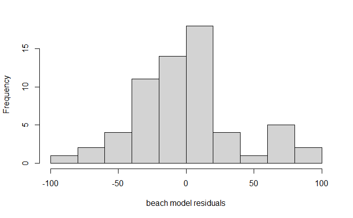

```r
#Plot the resiudals and inspect for normality
hist(Beach_Res, xlab = "beach model residuals", main = NULL)
```

### Question 2

#### Calculate test statistics for your regression coefficients. Verify by comparing to test statistics reported from model output.

```r
#Calculate Test Statistics for ALL coeficients
# Intercept
t_int <- coef(fit)[1] / summary(fit)[['coefficients']]['(Intercept)', 'Std. Error']

# Years
t_y <- coef(fit)[2] / summary(fit)[['coefficients']]['Year', 'Std. Error']

#BeachIDB
t_IDB <- coef(fit)[3] / summary(fit)[['coefficients']]['BeachIDB', 'Std. Error']

#BeachIDC
t_IDC <- coef(fit)[4] / summary(fit)[['coefficients']]['BeachIDC', 'Std. Error']

#Year:BeachIDB
t_YearIDB <- coef(fit)[5] / summary(fit)[['coefficients']]['Year:BeachIDB', 'Std. Error']

#Year:BeachIDC
t_YearIDC <- coef(fit)[6] / summary(fit)[['coefficients']]['Year:BeachIDC', 'Std. Error']

#final test-statistics
tstats <- data.frame(t_int, t_y, t_IDB, t_IDC, t_YearIDB, t_YearIDC)
tstats
```

|  | t_int | t_y | t_IDB | t_IDC | t_YearIDB | t_YearIDC |
| --- | --- | --- | --- | --- | --- | --- |
| (Intercept) | 14.50278 | -14.44263 | -9.496986 | -7.988032 | 9.478096 | 7.992408 |

### Question 3

#### Calculate p-values for your regression coefficients. Verify by comparing to p-values reported from model output. What are the associated null hypotheses? Do you reject or fail to reject these null hypotheses?

```r
#Degrees of freedom is "n-k" where is k is the number of regression coefficients and n is the number of samples or observations
k <- 6
n <- 62
df <- n-k
df
```

```
[1] 56
```

```r
#Intercept P-Value calculation
int_pval <- pt(-1 * abs(t_int), df = 56) + (1 - pt(abs(t_int), df = 56))

#Year P-value calculation
year_pval <- pt(-1 * abs(t_y), df = 56) + (1 - pt(abs(t_y), df = 56))

#BeachIDB P-value calculation
BeachB_pval <- pt(-1 * abs(t_IDB), df = 56) + (1 - pt(abs(t_IDB), df = 56))

#BeachIDC P-value calculation
BeachC_pval <- pt(-1 * abs(t_IDC), df = 56) + (1 - pt(abs(t_IDC), df = 56))

#Year:BeachIDB P-value calculation
YearBeachB_pval <- pt(-1 * abs(t_YearIDB), df = 56) + (1 - pt(abs(t_YearIDB), df = 56))

#Year:BeachIDC P-value calculation
YearBeachC_pval <- pt(-1 * abs(t_YearIDC), df = 56) + (1 - pt(abs(t_YearIDC), df = 56))

#Combine all P-values for easy comparison
Beach_Pval <- data.frame(int_pval, year_pval, BeachB_pval, BeachC_pval, YearBeachB_pval, YearBeachC_pval)
Beach_Pval
```

|  | int_pval | year_pval | BeachB_pval | BeachC_pval | YearBeachB_pval | YearBeachC_pval |
| --- | --- | --- | --- | --- | --- | --- |
| (Intercept) | 6.480982e-21 | 7.79403e-21 | 2.868446e-13 | 8.090199e-11 | 3.073734e-13 | 7.957167e-11 |

#### The associated null hypotheses for all of these coefficients is B1-6 = 0. We reject all of the null hypotheses with an assumed alpha-level = 0.05

### Question 4

#### Select a single regression coefficient (your choice) and devise a null hypothesis that is different from the default in lm(). Report the test statistics, your p-value, and whether you reject or fail to reject your null hypothesis.

#### The coefficient I am interested in testing is the BeachIDB coefficient. My new null hypothesis is B2 = -1000.

```r
t_IDBnew <- (coef(fit)[3]- (-1000)) / summary(fit)[['coefficients']]['BeachIDB', 'Std. Error']
t_IDBnew
```

```
 BeachIDB
-9.219394
```

```r
#P-value
BeachB_pvalnew <- pt(-1 * abs(t_IDBnew), df = 56) + (1 - pt(abs(t_IDBnew), df = 56))
BeachB_pvalnew
```

```
    BeachIDB
7.986881e-13
```

#### Based on the null hypothesis and an alpha-level = 0.05 I would reject the null hypothesis: B2 = -1000.

### Question 5

#### Interpret output of your fitted model. Tell me how beach area does (or does not change) through time at each of the 3 beaches.

##### Note: The original beach.csv data set used years (1992, 1993, 1994, etc.) as a variable but R does not read these values as years but as raw integers. This creates a model output that is difficult to interpret and relate to open beach hectares. A second version of the dataset has been created where years are now listed (1, 2, 3, etc.) and this makes the model much more readable for the average person (and me).

```r
summary(fit2)
```

```
Call:
lm(formula = OpenBeach ~ Year * BeachID, data = beach2)

Residuals:
    Min      1Q  Median      3Q     Max
-80.203 -21.460  -1.434  13.385  89.529

Coefficients:
              Estimate Std. Error t value Pr(>|t|)
(Intercept)    381.180     18.068  21.097  < 2e-16 ***
Year           -18.365      1.272 -14.443  < 2e-16 ***
BeachIDB      -279.824     25.500 -10.973 1.42e-15 ***
BeachIDC      -162.812     25.500  -6.385 3.57e-08 ***
Year:BeachIDB   17.043      1.798   9.478 3.07e-13 ***
Year:BeachIDC   14.371      1.798   7.992 7.96e-11 ***
---
Signif. codes:  0 ‘***’ 0.001 ‘**’ 0.01 ‘*’ 0.05 ‘.’ 0.1 ‘ ’ 1

Residual standard error: 39.46 on 56 degrees of freedom
Multiple R-squared:  0.8298,    Adjusted R-squared:  0.8146
F-statistic: 54.62 on 5 and 56 DF,  p-value: < 2.2e-16
```

#### The **Year:BeachB coefficient** is a positive value showing the effect of time has on open beach area on BeachB in reducing open area beach loss 17 hectares per year. The p-value is significant which shows that the effects of BeachB on yearly open beach loss is significant.

#### the **Year:BeachC coefficient** has a positive value showing that time interacts with BeachC to reduce yearly open beach loss by 14.4 hectares per year. The p-value is less than 0.05 which means that this the interaction between BeachC and years is signficant.